# homework-5

## Homework 5

**Note: If this is one of your two late homework submissions, please indicate below; also indicate whether it is your first or second late submission.**

__________________________________

This homework assignment has **two parts**. In the first, you will practice building a recommender system; in the second, you'll practice training a neural network for image classification. I strongly advise using Lab 8 and Lab 9 for assistance as you work on this assignment. Make sure to **read the entire assignment**.

You also may need to use other functions. I encourage you to make use of available resources (including the Internet) to help you solve these problems. You can also work with your classmates. If you do work together, you must provide the names of those classmates below.

[Names of Collaborators (if any):]{.underline}

### Recommender Systems

We'll work with the data in `data/movies.csv` and `data/movie-ratings.csv`. `movies` contains a list of $9,737$ movies and their basic description – title, year of release, and genres, separated by vertical bars (for example, `Comedy|Romance`). `movie-ratings` contains ratings of movies by $610$ users, on a scale from $0$ to $5$.

The data come from this source at Kaggle: https://www.kaggle.com/datasets/gargmanas/movierecommenderdataset/

#### Exercise 1

Read both data files into Python. (You can also use R, if you prefer. If you do use R, I would recommend working with a smaller subset of the data.)

Movie title and year of release are in the same column. Create a new variable that represents year of release, as a four-digit number.

```python
import pandas as pd

movies = pd.read_csv('data/movies.csv')
movie_ratings = pd.read_csv('data/movie-ratings.csv')

movies['year'] = movies['title'].str.extract(r'\((\d{4})\)')

movies.head()
movie_ratings.head()
```

[output not shown]

#### Exercise 2

Create a histogram of year of release. How would you describe the shape of the distribution? When were the most movies released?

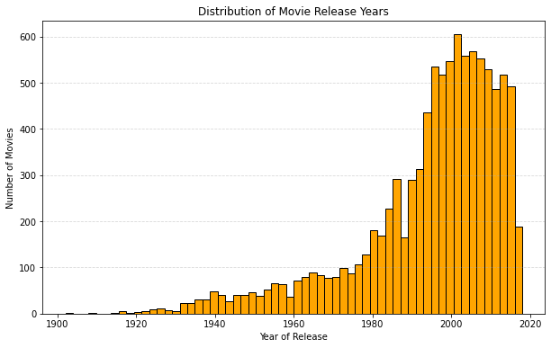

```python
import matplotlib.pyplot as plt


movies['year'] = pd.to_numeric(movies['year'])

plt.figure(figsize = (10, 6))
plt.hist(movies['year'], bins = 60, color = 'orange', edgecolor = 'black')
plt.title('Distribution of Movie Release Years')
plt.xlabel('Year of Release')
plt.ylabel('Number of Movies')
plt.grid(axis = 'y', linestyle = '--', alpha = 0.5)
plt.show()
```

The shape of the distribution of movie release year is left skewed, indicating that most of the movies in this data set were released closer to the current year. From the graph you can see that most movies were released sometime between the late 1980's until around 2019 where there is no movies contained in the data set released after that.

#### Exercise 3

Create a bar chart of the top 10 highest-rated movies.

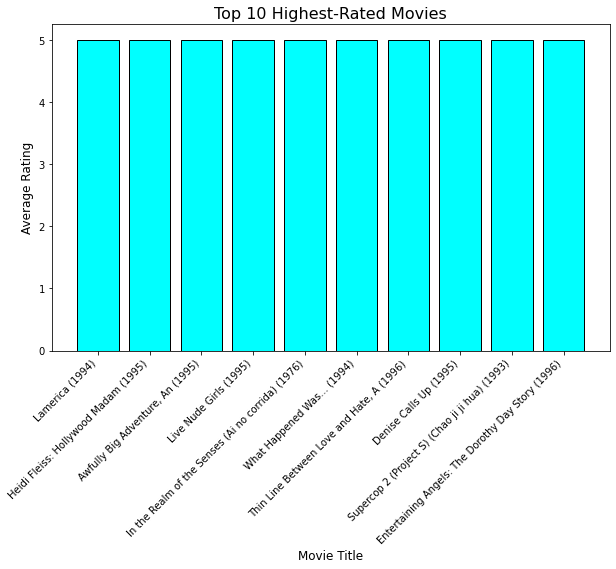

```python
average_ratings = movie_ratings.groupby('movieId')['rating'].mean()

top_10_movies = average_ratings.nlargest(10)

top_10_with_titles = movies[movies['movieId'].isin(top_10_movies.index)].copy()
top_10_with_titles['average_rating'] = top_10_movies.values

plt.figure(figsize = (10, 6))
plt.bar(top_10_with_titles['title'], top_10_with_titles['average_rating'], color = 'cyan', edgecolor = 'black')
plt.xticks(rotation = 45, ha = 'right')
plt.title('Top 10 Highest-Rated Movies', fontsize = 16)
plt.xlabel('Movie Title', fontsize = 12)
plt.ylabel('Average Rating', fontsize = 12)
plt.show()
```

#### Exercise 4

Create a variable called `string` that contains the text of each movie's genres, title, and year of release. For example, the value of `string` for `movieID == 3` should be: `"Adventure Children Fantasy Jumanji (1995)"`.

```python
movies['string'] = movies['genres'].str.replace('|', ' ', regex=False) + " " + movies['title']
```

#### Exercise 5

Using the `string` variable, create a tf-idf matrix with `TfidfVectorizer` and `tfv.fit`.

```python
from sklearn.feature_extraction.text import TfidfVectorizer

tfv = TfidfVectorizer()

tfidf_matrix = tfv.fit_transform(movies['string'])
```

#### Exercise 6

Use the sigmoid kernel from `scikit-learn` to calculate pairwise similarities between all items in your tf-idf matrix.

```python
from sklearn.metrics.pairwise import pairwise_kernels

similarity_matrix = pairwise_kernels(tfidf_matrix, metric='sigmoid')
```

#### Exercise 7

Define a function, `give_recommendation()`, that takes as input the title of a movie and returns the top 10 most similar movies.

```python
import numpy as np

def give_recommendation(movie_title, movies, similarity_matrix):
    movie_index = movies.index[movies['title'] == movie_title][0]

    similarity_scores = similarity_matrix[movie_index]

    top_indices = np.argsort(similarity_scores)[::-1][1:11]

    recommendations = [(movies.iloc[i]['title'], similarity_scores[i]) for i in top_indices]

    return recommendations
```

#### Exercise 8

What movies does your recommender system suggest for a user who likes "Toy Story" (released in 1995)?

```python
recommendations = give_recommendation("Toy Story (1995)", movies, similarity_matrix)

for i, (title, score) in enumerate(recommendations, start = 1):
    print(f"{i}. {title} (Similarity Score: {score:.4f})")
```

```
1. Toy Story 2 (1999) (Similarity Score: 0.7616)
2. Toy Story 3 (2010) (Similarity Score: 0.7616)
3. Toy, The (1982) (Similarity Score: 0.7616)
4. Toy Soldiers (1991) (Similarity Score: 0.7616)
5. NeverEnding Story, The (1984) (Similarity Score: 0.7616)
6. Wild, The (2006) (Similarity Score: 0.7616)
7. Jumanji (1995) (Similarity Score: 0.7616)
8. Balto (1995) (Similarity Score: 0.7616)
9. NeverEnding Story III, The (1994) (Similarity Score: 0.7616)
10. We're Back! A Dinosaur's Story (1993) (Similarity Score: 0.7616)
```

#### For 234 Students:

#### Exercise 9

Now we'll try making content-based recommendations. Turn the data into a CSR matrix using `scipy.sparse`.

#### Exercise 10

Fit a *k*-nearest neighbors model, using cosine similarity as the distance metric.

#### Exercise 11

Identify which movies your model deems most similar to "GoldenEye" (a James Bond movie, also released in 1995).

### Image Classification

Now we'll work with the data in `data/Animals`. This dataset, intended for animal image classification, [comes from Kaggle.](https://www.kaggle.com/datasets/borhanitrash/animal-image-classification-dataset) It consists of $3,000$ JPEG RGB images, each of which are 256 x 256 pixels, that have been divided into three classes with $1,000$ images in each class. The classes are `cats`, `dogs`, and `snakes`.

#### Exercise 12

Randomly select $150$ images of cats, $150$ images of dogs, and $150$ images of snakes. Set these aside in another directory labeled `test_images` to be your testing set. Using the same approach, randomly select another $150$ images from each class, and set these aside in a `validation_images` directory to be your validation set.

#### Exercise 13

Display a random image from each of the three classes in your training set to verify that the data are set up correctly.

```python
import numpy as np
import matplotlib.pyplot as plt
import pandas as pd
import tensorflow as tf
from tensorflow import keras
from keras.layers import *
from keras.models import *
from keras.preprocessing import image
from tensorflow.keras.preprocessing.image import ImageDataGenerator
import os, shutil
import warnings
warnings.filterwarnings('ignore')

train_path = '/Users/robeh/Documents/PSTAT 134/homework-5/data/Animals'
validation_path = "/Users/robeh/Documents/PSTAT 134/homework-5/data/validation_images"
test_path = '/Users/robeh/Documents/PSTAT 134/homework-5/data/test_images'

image_categories = os.listdir('/Users/robeh/Documents/PSTAT 134/homework-5/data/Animals')

def plot_images(image_categories):
    valid_categories = [
        cat for cat in image_categories
        if not cat.startswith(".") and os.path.isdir(os.path.join(train_path, cat))
    ]

    # create a figure
    plt.figure(figsize=(12, 12))
    for i, cat in enumerate(valid_categories):

        # load images for the ith category
        image_path = train_path + '/' + cat
        images_in_folder = os.listdir(image_path)
        first_image_of_folder = images_in_folder[0]
        first_image_path = image_path + '/' + first_image_of_folder
        img = image.load_img(first_image_path)
        img_arr = image.img_to_array(img)/255.0

        # create subplot and plot the images
        plt.subplot(1, 3, i+1)
        plt.imshow(img_arr)
        plt.title(cat)
        plt.axis('off')

    plt.show()
```

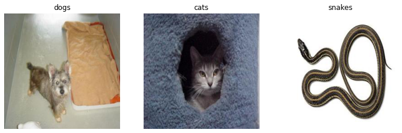

```python
plot_images(image_categories)
```

#### Exercise 14

Using `ImageDataGenerator` and `flow_from_directory`, rescale your training, testing, and validation sets. Load and preprocess your images in batches of size $10$.

```python
# Training set
train_gen = ImageDataGenerator(rescale = 1.0/255.0) # scale the data
train_image_generator = train_gen.flow_from_directory(train_path,
                                                      target_size = (150, 150),
                                                      batch_size = 32,
                                                      class_mode = 'categorical')

# Validation set
val_gen = ImageDataGenerator(rescale = 1.0/255.0) # scale the data
val_image_generator = train_gen.flow_from_directory(validation_path,
                                                    target_size = (150, 150),
                                                    batch_size = 32,
                                                    class_mode = 'categorical')

# Testing set
test_gen = ImageDataGenerator(rescale = 1.0/255.0) # scale the data
test_image_generator = train_gen.flow_from_directory(test_path,
                                                     target_size = (150, 150),
                                                     batch_size = 32,
                                                     class_mode = 'categorical')
```

```
Found 2100 images belonging to 3 classes.
Found 450 images belonging to 3 classes.
Found 450 images belonging to 3 classes.
```

#### Exercise 15

Set up a convolutional neural net (CNN) with 7 layers using `Sequential()`. The layers should be as follows:

1. 2D convolutional input layer with a ReLU activation function;
2. Max pooling layer for 2D spatial data;
3. 2D convolutional layer with ReLU activation;
4. Max pooling layer for 2D spatial data;
5. Flattening layer;
6. Dense layer with $128$ units and ReLU activation;
7. Dense output layer with softmax activation.

```python
model = Sequential()

model.add(Conv2D(filters = 32, kernel_size = 3, strides = 1,
                 padding = 'same', activation = 'relu',
                 input_shape = [150, 150, 3]))
model.add(MaxPooling2D(pool_size = (2, 2)))

model.add(Conv2D(filters = 64, kernel_size = 3, strides = 1,
                 padding = 'same', activation = 'relu'))
model.add(MaxPooling2D(pool_size = (2, 2)))

model.add(Conv2D(filters = 128, kernel_size = 3, strides = 1,
                 padding = 'same', activation = 'relu'))
model.add(MaxPooling2D(pool_size = (2, 2)))

model.add(Flatten())

model.add(Dense(128, activation = 'relu'))
model.add(Dropout(0.25))
model.add(Dense(64, activation = 'relu'))
model.add(Dense(3, activation = 'softmax'))

model.summary()
```

```
Model: "sequential_1"
```

```
┏━━━━━━━━━━━━━━━━━━━━━━━━━━━━━━━━━┳━━━━━━━━━━━━━━━━━━━━━━━━┳━━━━━━━━━━━━━━━┓
┃ Layer (type)                    ┃ Output Shape           ┃       Param # ┃
┡━━━━━━━━━━━━━━━━━━━━━━━━━━━━━━━━━╇━━━━━━━━━━━━━━━━━━━━━━━━╇━━━━━━━━━━━━━━━┩
│ conv2d_3 (Conv2D)               │ (None, 150, 150, 32)   │           896 │
├─────────────────────────────────┼────────────────────────┼───────────────┤
│ max_pooling2d_3 (MaxPooling2D)  │ (None, 75, 75, 32)     │             0 │
├─────────────────────────────────┼────────────────────────┼───────────────┤
│ conv2d_4 (Conv2D)               │ (None, 75, 75, 64)     │        18,496 │
├─────────────────────────────────┼────────────────────────┼───────────────┤
│ max_pooling2d_4 (MaxPooling2D)  │ (None, 37, 37, 64)     │             0 │
├─────────────────────────────────┼────────────────────────┼───────────────┤
│ conv2d_5 (Conv2D)               │ (None, 37, 37, 128)    │        73,856 │
├─────────────────────────────────┼────────────────────────┼───────────────┤
│ max_pooling2d_5 (MaxPooling2D)  │ (None, 18, 18, 128)    │             0 │
├─────────────────────────────────┼────────────────────────┼───────────────┤
│ flatten_1 (Flatten)             │ (None, 41472)          │             0 │
├─────────────────────────────────┼────────────────────────┼───────────────┤
│ dense_3 (Dense)                 │ (None, 128)            │     5,308,544 │
├─────────────────────────────────┼────────────────────────┼───────────────┤
│ dropout_1 (Dropout)             │ (None, 128)            │             0 │
├─────────────────────────────────┼────────────────────────┼───────────────┤
│ dense_4 (Dense)                 │ (None, 64)             │         8,256 │
├─────────────────────────────────┼────────────────────────┼───────────────┤
│ dense_5 (Dense)                 │ (None, 3)              │           195 │
└─────────────────────────────────┴────────────────────────┴───────────────┘
```

```
 Total params: 5,410,243 (20.64 MB)
```

```
 Trainable params: 5,410,243 (20.64 MB)
```

```
 Non-trainable params: 0 (0.00 B)
```

#### Exercise 16

Using Adam and categorical cross-entropy, fit the network you've created and let it run for $12$ epochs.

```python
model.compile(optimizer = 'adam', loss = 'categorical_crossentropy', metrics = ['accuracy'])

history = model.fit(
    train_image_generator,
    epochs = 12,
    validation_data = val_image_generator
)
```

```
66/66 ━━━━━━━━━━━━━━━━━━━━ 36s 514ms/step - accuracy: 0.3883 - loss: 1.1163 - val_accuracy: 0.4511 - val_loss: 1.0037
66/66 ━━━━━━━━━━━━━━━━━━━━ 35s 527ms/step - accuracy: 0.5567 - loss: 0.8875 - val_accuracy: 0.5978 - val_loss: 0.7792
66/66 ━━━━━━━━━━━━━━━━━━━━ 37s 555ms/step - accuracy: 0.6272 - loss: 0.7458 - val_accuracy: 0.6556 - val_loss: 0.7160
66/66 ━━━━━━━━━━━━━━━━━━━━ 45s 681ms/step - accuracy: 0.6902 - loss: 0.6403 - val_accuracy: 0.6756 - val_loss: 0.6870
66/66 ━━━━━━━━━━━━━━━━━━━━ 38s 573ms/step - accuracy: 0.7175 - loss: 0.6342 - val_accuracy: 0.7111 - val_loss: 0.6285
66/66 ━━━━━━━━━━━━━━━━━━━━ 40s 600ms/step - accuracy: 0.7959 - loss: 0.4721 - val_accuracy: 0.6556 - val_loss: 0.7250
66/66 ━━━━━━━━━━━━━━━━━━━━ 37s 559ms/step - accuracy: 0.8166 - loss: 0.4298 - val_accuracy: 0.7089 - val_loss: 0.7464
66/66 ━━━━━━━━━━━━━━━━━━━━ 37s 566ms/step - accuracy: 0.8675 - loss: 0.3180 - val_accuracy: 0.7000 - val_loss: 0.8068
66/66 ━━━━━━━━━━━━━━━━━━━━ 38s 579ms/step - accuracy: 0.9099 - loss: 0.2209 - val_accuracy: 0.6800 - val_loss: 0.9160
66/66 ━━━━━━━━━━━━━━━━━━━━ 39s 587ms/step - accuracy: 0.9483 - loss: 0.1489 - val_accuracy: 0.7289 - val_loss: 0.9530
66/66 ━━━━━━━━━━━━━━━━━━━━ 35s 531ms/step - accuracy: 0.9510 - loss: 0.1383 - val_accuracy: 0.6867 - val_loss: 1.1343
66/66 ━━━━━━━━━━━━━━━━━━━━ 38s 576ms/step - accuracy: 0.9566 - loss: 0.1176 - val_accuracy: 0.7067 - val_loss: 1.4423
```

#### Exercise 17

Create a plot of the accuracy and loss by the number of epochs.

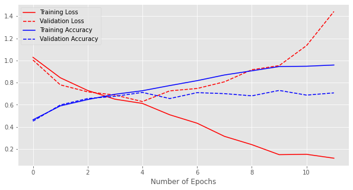

```python
h = history.history
plt.style.use('ggplot')
plt.figure(figsize=(10, 5))
plt.plot(h['loss'], c='red', label='Training Loss')
plt.plot(h['val_loss'], c='red', linestyle='--', label='Validation Loss')
plt.plot(h['accuracy'], c='blue', label='Training Accuracy')
plt.plot(h['val_accuracy'], c='blue', linestyle='--', label='Validation Accuracy')
plt.xlabel("Number of Epochs")
plt.legend(loc='best')
plt.show()
```

#### For 234 Students:

#### Exercise 18

Look at your model's accuracy on your testing set. How did it do?

#### Exercise 19

Generate your model's prediction for a random image from the dataset.

#### Exercise 20

Create a confusion matrix using your testing set. Visualize the matrix as a heat map. Which classes was your model best at predicting? Which was it worst at predicting? How do you know?